# Lab Week 1-3 with R: Basics of N=1 time series modeling

Noemi Schuurman

2024

## Introduction: Exercises for Week 1-3

In this lab you will put in practice the content we discussed in weeks 1-3 of MILD. You will take a look at time series data, evaluate and interpret descriptive statistics and plot for these data, and estimate N=1 time series models. Specifically you will fit AR(1) and AR(2) models, an AR(1) model with a covariate, and a VAR(1) model. We include different estimation techniques for these models, including both frequentist and Bayesian techniques. The Bayesian techniques will be helpful to provide you with a basis for once we move on to more complicated models and analyses in later weeks.

### The data we will work with

In this lab you will mainly work with real data from Schuurman, Houtveen and Hamaker (2015, Frontiers). These are daily diary measurements from two women, whom we refer to as Jane and Mary (not their real names). Both women’s data consist of about 100 consecutive days of repeated measurements, some days the scores are missing because they did not answer. The original data contains various measures on mood, positive and negative affect, and symptoms surrounding the women’s periods.

### Installing and loading packages

Some of the exercises in this lab make use of r-packages or other software you need to run via R.

Specifically you’ll need these r-packages: [foreign](https://cran.r-project.org/web/packages/foreign/index.html), for loading an SPSS data file; [psych](https://cran.r-project.org/web/packages/psych/index.html), for loading an SPSS data file; [rjags](https://cran.r-project.org/web/packages/rjags/index.html), for fitting the Bayesian models; [coda](https://cran.r-project.org/web/packages/coda/index.html), for running summary stats and plots on the Bayesian analysis results.

And you’ll need this additional piece of software (outside of R): [JAGS](https://sourceforge.net/projects/mcmc-jags/), because rjags depends on this program. JAGS is software for fitting Bayesian models, and you will use it via r with package rjags.

```r
# If you do not have the below packages, you can download them using the install.packages() command (just copy the code behind the hashtags below, and paste into the R console).
# install.packages("foreign")
# install.packages("rjags")
# install.packages("coda")
# install.packages("psych")


library(foreign)
library(rjags)
library(coda)
#library(psych)
```

## 1. Introduction to intensive longitudinal data

### 1.1 Loading the data

The data are in two SPSS files, which can be loaded with help from package `foreign`:

```r
mydata_Jane= read.spss("dat2.sav", use.value.labels = FALSE,
                       to.data.frame = FALSE,
                       trim.factor.names = FALSE,
                       trim_values = TRUE, reencode = NA,
                       use.missings = TRUE)
```

```
## re-encoding from CP1252
```

```r
mydata_Mary= read.spss("dat4.sav", use.value.labels = FALSE,
                       to.data.frame = FALSE,
                       trim.factor.names = FALSE,
                       trim_values = TRUE, reencode = NA,
                       use.missings = TRUE)
```

```
## re-encoding from CP1252
```

This may return a warning about a “record type 7”, but this warning can be ignored.

First, we’ll extract the variables from the original data we will work with for the first few exercises: We start by looking at both women’s rating of their daily overall mood, scored from 0 (worst ever) to 100 (best ever).

```r
###Extracting mood from Jane's dataset##
dat_Jane <- data.frame(mydata_Jane$scale)
dat_Jane <- as.matrix(dat_Jane)
colnames(dat_Jane) <- c("mood")

###Extracting mood from Mary's dataset##
dat_Mary <- data.frame(mydata_Mary$scale)
dat_Mary <- as.matrix(dat_Mary)
colnames(dat_Mary) <- c("mood")
```

### 1.2 Exploring the data with plots and descriptives

In the following exercises, we’ll specify the code for various plots and descriptive statistics for the time series data of Jane. You can do the same thing for Mary’s data.

#### 1.2a Take a look at the data

View the univariate time series for Jane’s variable `mood`:

```r
View(dat_Jane)
```

- What do you notice?
- Try out the same for Mary.

#### 1.2b Visualize the time series with a time series plot

We start by making a time series plot for Jane’s mood, which is a plot with the scores on the y-axis, and time (here days) on the x-axis. We do this in R using:

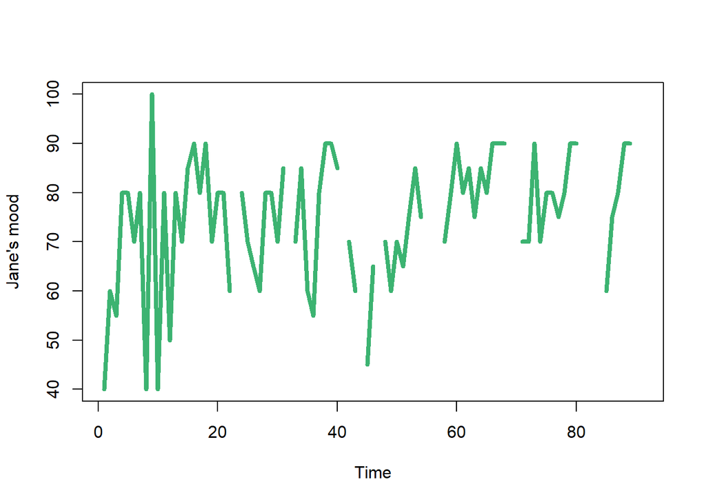

```r
ts.plot(dat_Jane,col="mediumseagreen",lwd=4, ylab= "Jane's mood")
```

- What do you notice?
- Do the same for Mary.

#### 1.2c Basic descriptive statistics

Now get the means, range, variance and standard deviation for Jane. Also determine how many of the observations are missing:

```r
###Basic descriptives for Jane:
mean(dat_Jane, na.rm=TRUE)
```

```
## [1] 74.93421
```

```r
range(dat_Jane, na.rm=TRUE)
```

```
## [1]  40 100
```

```r
var(dat_Jane, na.rm=TRUE)
```

```
##          mood
## mood 173.6623
```

```r
sd(dat_Jane, na.rm=TRUE)
```

```
## [1] 13.1781
```

```r
### missing observations
sum(is.na(dat_Jane)) #is.na() codes if an observation is an NA (1) or not (0). By taking the sum over this function, we count the number of NA's in the data.
```

```
## [1] 15
```

```r
mean(is.na(dat_Jane)) #by taking the mean of is.na, we get the proportion of NA's in the data.
```

```
## [1] 0.1648352
```

- Do the same for Mary. How do Jane’s and Mary’s descriptives compare? Does it match your intuition for what you saw from the plot?

#### 1.2d Typicaly time series descriptives: the ACF and PACF

We can get the autocorrelation function (ACF), and the and partial autocorrelation functions (PACF) for the data of each woman using the functions `acf()`, and `pacf()` in R.

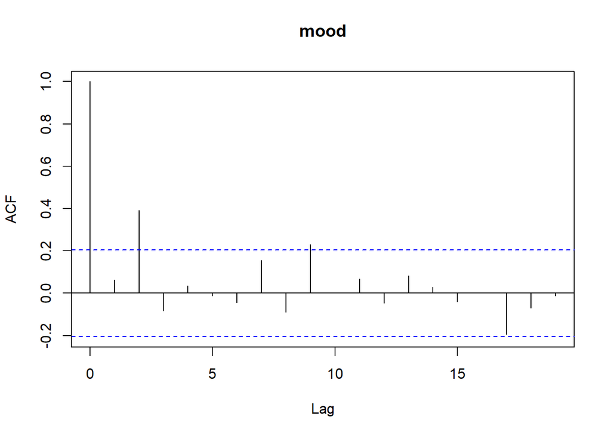

```r
acf(dat_Jane,na.action=na.pass)
```

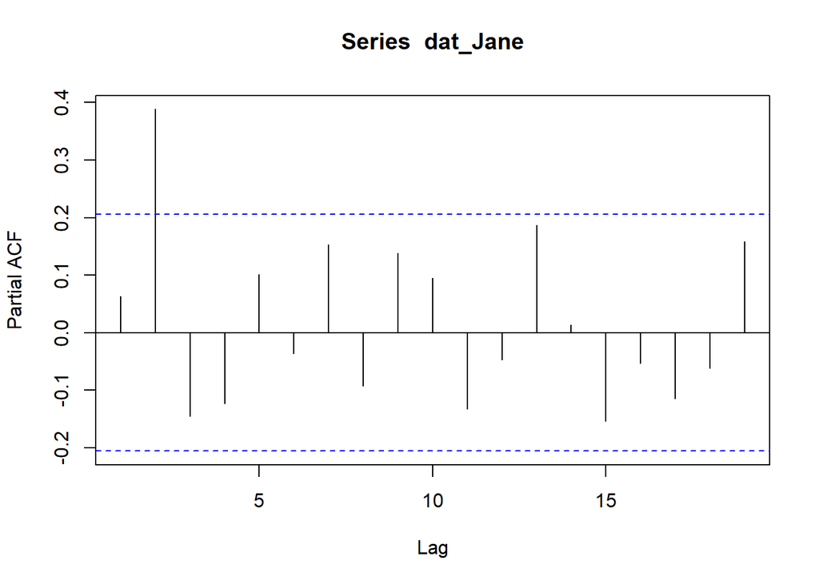

```r
pacf(dat_Jane,na.action=na.pass)
```

- Interpret and compare the results of both functions for Jane.
- Do the same for Mary.
- Based on the results of these functions, what order of autoregressive model would you fit for each of them (i.e., how many lags would you like to include)? (You could save this question for when you have learned more about time series models)

## 2. Introduction to time series analysis for single cases (n=1) and single variables

In the following we will try out fitting time series models to mood time series for Jane and Mary (separately). We will start by using different estimation methods common in classical statistics. Later on, we’ll try Bayesian models.

### 2.1 AR models using least squares estimation

The simplest way to fit a N=1 autoregressive model is estimating it as a linear regression model using least squares with the `lm()` function. In order to do this, we need to first create the lagged predictor variables that can be used to predict y(t).

We’ll stick to fitting an AR(1) model with this technique (although you could try out an AR model with more lags!). Below is code to create the lagged variable we need as our predictor variable, namely our original variable shifted one point in time. We first make a function to lag variables, which is then applied to the data of Jane.

```r
lagmatrix <- function(x,max.lag)
  embed(c(rep(NA,max.lag), x), max.lag+1)

y1L_Jane <- lagmatrix(dat_Jane,1)[,2]

cbind(dat_Jane,y1L_Jane)
```

```
##       mood y1L_Jane
##  [1,]   40       NA
##  [2,]   60       40
##  [3,]   55       60
##  [4,]   80       55
##  [5,]   80       80
##  [6,]   70       80
##  [7,]   80       70
##  [8,]   40       80
##  [9,]  100       40
## [10,]   40      100
## [11,]   80       40
## [12,]   50       80
## [13,]   80       50
## [14,]   70       80
```

[output cut: 77 more lines]

- Compare these two variables: They are y(t) and its lagged version y(t-1). Because these are daily diary data, we could also refer to them as: today’s scores and yesterday’s scores.

Now that we have our lagged predictor variable, we could correlate it with our original variable to obtain the lag 1 autocorrelation (or we could use the acf function in the previous exercise!). We can also visualize this correlation with a scatter plot:

```r
cor(dat_Jane,y1L_Jane,use="complete")
```

```
##            [,1]
## mood 0.07136963
```

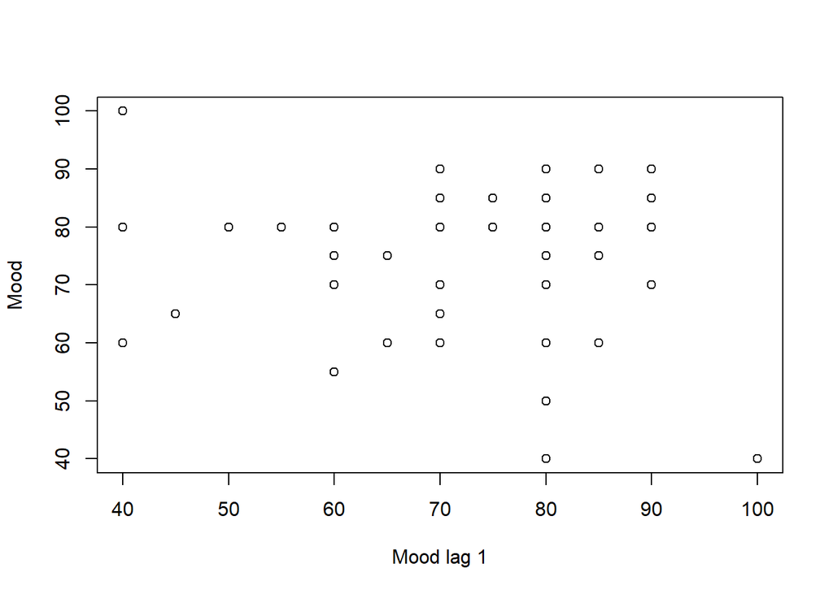

```r
plot(y=dat_Jane,x=y1L_Jane,xlab ="Mood lag 1",ylab="Mood" )
```

Moreover, we can now regress y(t) on y(t-1) using least squares in `lm()` and hence fit the AR(1) model:

```r
ar1_in_lm<-lm(dat_Jane~y1L_Jane)
summary(ar1_in_lm)
```

```
##
## Call:
## lm(formula = dat_Jane ~ y1L_Jane)
##
## Residuals:
##     Min      1Q  Median      3Q     Max
## -38.021  -6.667   3.333   8.925  26.039
##
## Coefficients:
##             Estimate Std. Error t value Pr(>|t|)
## (Intercept) 71.25396    8.93122   7.978 3.52e-11 ***
## y1L_Jane     0.06767    0.11821   0.572    0.569
## ---
## Signif. codes:  0 '***' 0.001 '**' 0.01 '*' 0.05 '.' 0.1 ' ' 1
##
## Residual standard error: 12.66 on 64 degrees of freedom
##   (25 observations deleted due to missingness)
## Multiple R-squared:  0.005094,   Adjusted R-squared:  -0.01045
## F-statistic: 0.3277 on 1 and 64 DF,  p-value: 0.569
```

The regression coefficient is the lag 1 autoregressive parameter. Note that for a simple AR(1) model, without missing data, this regression coefficient will be the same as the autocorrelation at lag 1. Here, they deviate a bit, due to the missings in the data.

- Interpret the results.
- Do the same analysis for Mary, and interpret the results.

### 2.2 Autoregressive modeling using function `arima`

We can easily fit N=1 time series models with package `arima` which is native in R (i.e., it does not need to be installed or loaded). ARIMA uses a state space modeling framework which combines maximum likelihood estimation and the kalman filter to fit time series models. As a result, it will handle missing data more elegantly than the approach based on `lm()` and least squares, which simply deletes all cases that have missings on either the outcome y(t) or the predictor y(t-1). Use ?arima in R to learn more and check out the default options.

#### Fitting an AR(1) model with arima

You can fit an AR(1) model to the data of Jane using:

```r
arima(dat_Jane, c(1,0,0))
```

```
##
## Call:
## arima(x = dat_Jane, order = c(1, 0, 0))
##
## Coefficients:
##          ar1  intercept
##       0.0752    74.8807
## s.e.  0.1321     1.6063
##
## sigma^2 estimated as 170.5:  log likelihood = -303.15,  aic = 612.29
```

The three numbers in `c(1,0,0)` signify in order:

- the number of lags you want in terms autoregressive coefficients (the `ar` part of arima models) for your time series model. Here we have indicated we want a lag 1 autoregressive effect and nothing more.
- the level of integration you want for your time series model (the `i` part of arima models), which is not currently covered in this course, and pertains to specific types of non-stationarity. We have put it to zero, because we do not want an integrated model here, but a simple AR(1) model.
- the number of moving average terms you want, that is, the number of lags you want in terms of movering average effects. We have put it to zero, because we do not want moving average effects here.

Given this information:

- Interpret the results. Compare the results with those obtained with the least squares approach used above.
- Do the same for Mary.

- Next, fit an AR(2) model for Jane and Mary using `arima()`.

An AR(2) can be run using:

```r
arima(dat_Jane, c(2,0,0))
```

```
##
## Call:
## arima(x = dat_Jane, order = c(2, 0, 0))
##
## Coefficients:
##          ar1     ar2  intercept
##       0.0840  0.4070    74.7038
## s.e.  0.1053  0.1089     2.4736
##
## sigma^2 estimated as 141.8:  log likelihood = -297.22,  aic = 602.43
```

- Interpret the results for both Mary and Jane.
- Use the reported information criteria with these results, and the ones for the AR(1) model, to select the best model for Mary, and the best model for Jane.
- If you want, you can try out more models!

## 3. Delving deeper into autoregressive modeling

For the following exercises, we turn to Bayesian analysis using `JAGS` (software outside of R), via package `rjags`. Or if you like, you can now switch to our lab in Mplus for week 1-3, which is also based on Bayesian techniques.

An advantage of using Bayesian analyses is that we can easily extend models to incorporate covariates, multivariate outcomes, latent variables, or multiple subjects. In these exercises however, we’ll still stick to relatively simple, single case, autoregressive models for single variables.

In that context, we have as an advantage that instead of specifying the AR(1) model in one equation with an intercept, we can specify it in two equations, in which the first is used to center the data (by subtracting the mean from each observed score), and the second equation is used to specify the AR(1) model on the centered data. Note we are not using the samlpe mean to center the data, but we estimate this mean as part of the model: We use latent centering (a best practice for centering).

If you are not familiar with Bayesian analyses and/or JAGS, it is a good idea to first read our informal intro to Bayesian analysis.

### 3.1 The Bayesian AR(1) model

The autoregressive model we fill fit here has three parameters that we’ll estimate: the mean, the autoregressive parameter, and the variance of the residuals (i.e., the innovation variance). That is, we estimate the same number of parameters as before, but rather than an intercept, we directly estimate the mean.

#### 3.1.a Specifying the model

This is the JAGS code for the model (everything in between parentheses), which we will supply to JAGS for the analysis (it is provided as a text file with the lab files, make sure it is in your working directory). Take a look at the model specification, including the priors that were specified. The priors specified are intended to be uninformative (i.e., flat and wide).

```r
cat("model{


#####likelihood or data model######
    for (t in 2:nt)
    ## model for timepoint 2 onwards
    {
        y[t]~dnorm(muy[t],Ipre) ## Ipre is the innovation precision
        z[t] <- y[t] - mu ## z[t] are centered scores
        muy[t]<- mu + phi*z[t-1] ## mu is mean, phi is autoregressive parameter
    }

####timepoint 1#######
 ## defining things needed for time point one.
    z[1] <- y[1]-mu

####priors###########
    Ipre <- inverse(Ivar) ## innovation precision
    Ivar ~dunif(0,300)   ##innovation variance
    phi~dunif(-1,1) ## autoregression coefficient
    mu~dnorm(50,.001) ## mean
}

")
```

```
## model{
##
##
## #####likelihood or data model######
##  for (t in 2:nt)
##  ## model for timepoint 2 onwards
##  {
##      y[t]~dnorm(muy[t],Ipre) ## Ipre is the innovation precision
##      z[t] <- y[t] - mu ## z[t] are centered scores
##      muy[t]<- mu + phi*z[t-1] ## mu is mean, phi is autoregressive parameter
##  }
##
## ####timepoint 1#######
##  ## defining things needed for time point one.
##  z[1] <- y[1]-mu
##
## ####priors###########
##     Ipre <- inverse(Ivar) ## innovation precision
##     Ivar ~dunif(0,300)   ##innovation variance
##     phi~dunif(-1,1) ## autoregression coefficient
##     mu~dnorm(50,.001) ## mean
## }
```

- If you are not familiar with Bayesian analyses and/or JAGS, it is a good idea to first read our informal intro to Bayesian analysis available on the Ulearning platform.
- What do you think of our prior specifications, given what you know of the measurement scale we are using for mood?

We will fit the model in JAGS via package `rjags` with three chains. For each chain, initial values for each parameter can be specified in lists as follows:

```r
ins = list(list(phi=.6, Ivar=100, mu=50),
           list(phi=.3, Ivar=60, mu=60),
           list(phi=-.2, Ivar=80, mu=70))
```

It is also possible to not specify any starting values, in which case they will be generated by JAGS based on the specified priors.

We also need to specify the length of the time series `nt` and provide it to JAGS as data, because this quantity is used in the model code in the for loop. We specify this as follows (and we’ll add this to the data for JAGS later):

```r
nt=length(dat_Jane)
```

Now we have everything needed to run the model. We use the function `jags.model()` to compile the model for JAGS. This requires us to specify:

1. the model file (given above)
2. data to be used with the model file (for Jane), including nt
3. initial values if we want to provide them
4. the number of chains we want to use

```r
jags_AR1 <- jags.model('AR1model.txt',
                       data = list('nt' = nt,
                                   'y' = as.numeric(dat_Jane)),
                       inits = ins,
                       n.chains = 3)
```

#### 3.1.b Running the model

Now we have specified our JAGS model, we can get Bayesian samples from it. We first do 1000 samples (i.e., iterations) for burn-in purposes for each chain.

```r
update(jags_AR1, 1000)
```

Next, we ask for 2000 additional samples per chain on which we will base our results. We save the samples and obtain the results for parameters phi, mu, and Ivar (autoregressive coefficient, mean, and innovation variance):

```r
samps_AR1 <- coda.samples(model = jags_AR1,
                          variable.names = c('phi','mu','Ivar'),
                          n.iter = 2000)
```

#### 3.1.c Checking convergence

Now we have to do some convergence checks. Specifically, we check

1. trace plots, which should look like fat caterpillars, with good overlap (mixing) of the different chains (represented by different colors)
2. the Gelman-Rubin statistics (plots and summary stats), which should be very close to 1 (smaller than 1.05)
3. the density plots, which should look smooth and unimodal

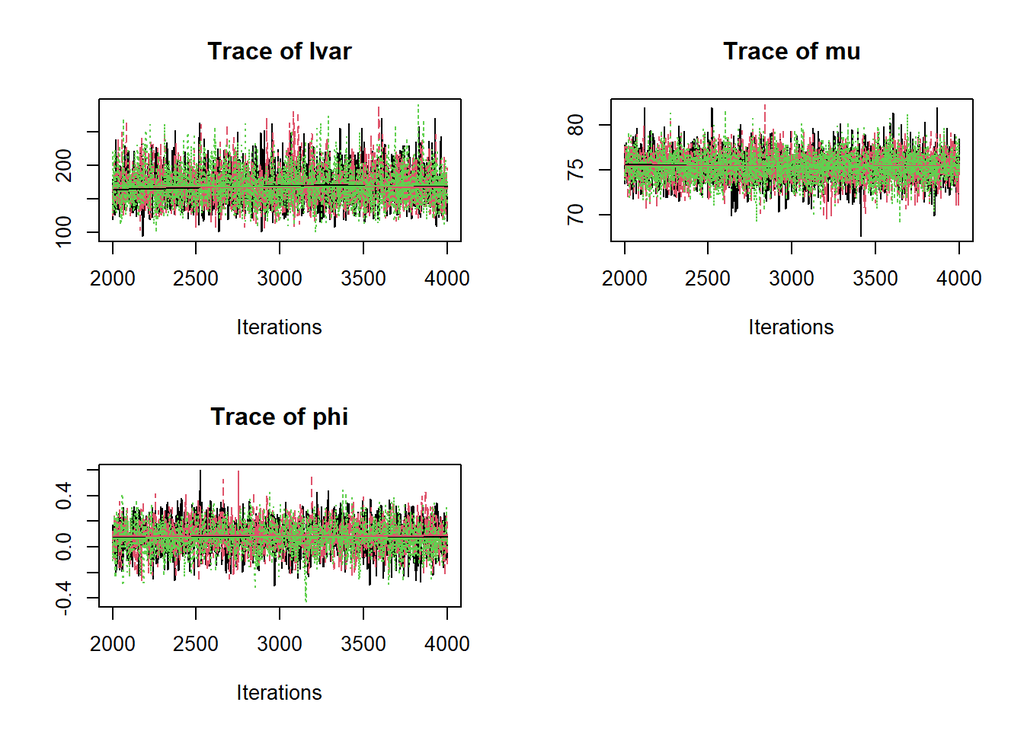

```r
plot(samps_AR1,density=FALSE)
```

```r
gelman.diag(samps_AR1)
```

```
## Potential scale reduction factors:
##
##      Point est. Upper C.I.
## Ivar          1       1.00
## mu            1       1.00
## phi           1       1.01
##
## Multivariate psrf
##
## 1
```

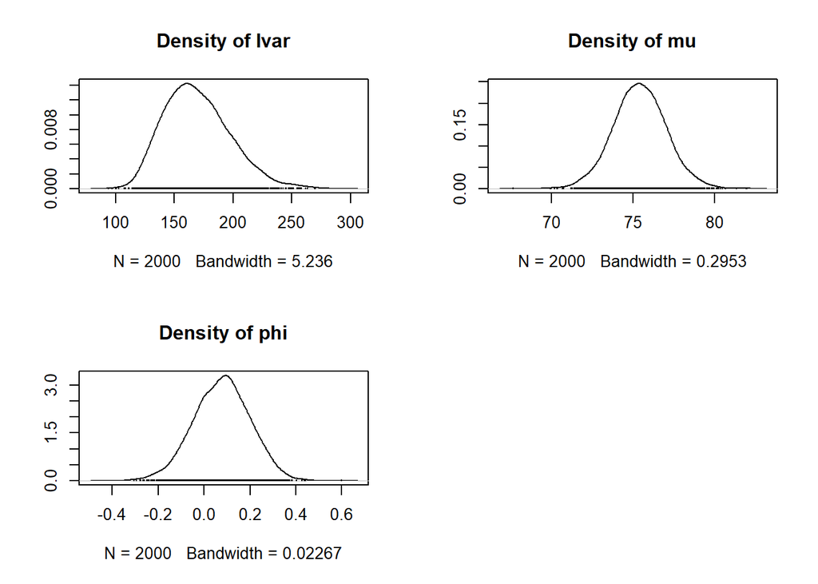

```r
plot(samps_AR1,trace=FALSE)
```

The density plots are nice and smooth, trace plots look like fat caterpillars, gelman-rubin statistics are good. Convergence seems in order.

#### 3.1.d Parameter estimates

Now that we have evaluated our convergence positively, we can take a look at our parameter estimates:

```r
summary(samps_AR1)
```

```
##
## Iterations = 2001:4000
## Thinning interval = 1
## Number of chains = 3
## Sample size per chain = 2000
##
## 1. Empirical mean and standard deviation for each variable,
##    plus standard error of the mean:
##
##           Mean      SD Naive SE Time-series SE
## Ivar 169.67201 28.1392 0.363276       0.573216
## mu    75.40120  1.6376 0.021142       0.024469
## phi    0.07704  0.1227 0.001584       0.002612
##
## 2. Quantiles for each variable:
##
##          2.5%        25%       50%      75%    97.5%
## Ivar 123.7034 149.153182 166.84965 187.1464 231.3409
## mu    72.1171  74.337421  75.38563  76.4639  78.6746
## phi   -0.1696  -0.003689   0.07985   0.1596   0.3093
```

In the summary results you find the mean estimate for each parameter and the posterior standard deviation, and the quantiles for the posterior distribution. The first and last quantile in the results can be used to form the lower and upper bound of a 95% credible interval for each parameter.

- Interpret the results.
- Are the results similar to those from arima and OLS procedure?

#### 3.1.e Bonus: Rerun the model

Rerun the model with a larger number of burn-in and iterations. If the model has converged, the results should be almost the same.

- Did the results change?
- Fit the Bayesian AR(1) model for Mary.
- If you like, you can experiment with different the priors and starting values. Does it affect the results?

###3.2 Bayesian AR(2) analysis Next, we will fit the AR(2) model for Jane and Mary. In this model, we regress the y(t) not only on y(t-1), but also on y(t-2); hence, both yesterday and the day before yesterday serve as predictors for today.

This model has 4 parameters: the mean of the variables, the two autoregressive parameters, and the variance of the residuals.

#### 3.2a Specifying the model

An AR(2) model can be specified using (this is provided in a text file with the lab exercises, store it in your working directory):

```r
cat("model{


#####model######
    for (t in 3:nt)
    ### model for timepoint 3 onwards
    {
        y[t] ~ dnorm(muy[t],Ipre) ## Ipre is innovation precision
        z[t] <- y[t]-mu #centered scores
        muy[t] <- mu + phi1*z[t-1] + phi2*z[t-2] ## mu is mean, phi1 and phi2 are the autregressive parameters


    }

####timepoint 1 and 2 #######

    z[1] <- y[1] - mu ### model for time point one
    z[2] <- y[2] - mu ### model for time point two


####priors###########

    Ipre <- inverse(Ivar) ## innovation precision as function of the variance
    Ivar ~ dunif(0,300)   ##prior for innovation variance

    phi1 ~ dunif(-1,1) ## prior for lag 1 autoregression coefficient
      phi2 ~ dunif(-1,1) ## prior for lag 2 autoregression coefficient
    mu ~ dnorm(50,.001) ## prior for the mean



}

")
```

```
## model{
##
##
## #####model######
##  for (t in 3:nt)
##  ### model for timepoint 3 onwards
##  {
##      y[t] ~ dnorm(muy[t],Ipre) ## Ipre is innovation precision
##      z[t] <- y[t]-mu #centered scores
##      muy[t] <- mu + phi1*z[t-1] + phi2*z[t-2] ## mu is mean, phi1 and phi2 are the autregressive parameters
##
##
##     }
##
## ####timepoint 1 and 2 #######
##
##  z[1] <- y[1] - mu ### model for time point one
##  z[2] <- y[2] - mu ### model for time point two
##
##
## ####priors###########
##
##     Ipre <- inverse(Ivar) ## innovation precision as function of the variance
##     Ivar ~ dunif(0,300)   ##prior for innovation variance
##
##     phi1 ~ dunif(-1,1) ## prior for lag 1 autoregression coefficient
##    phi2 ~ dunif(-1,1) ## prior for lag 2 autoregression coefficient
##     mu ~ dnorm(50,.001) ## prior for the mean
##
##
##
## }
```

Then we specify the sets of initial values for three chains:

```r
ins = list(list( phi1=.6, phi2=.2, Ivar=100,  mu=50),
           list( phi1=.3, phi2=-.5, Ivar=60,  mu=60),
           list( phi1=-.2, phi2=0, Ivar=80, mu=70))
```

and we compile the model:

```r
jags_AR2 <- jags.model('AR2model.txt',
                       data = list('nt' = nt,
                                   'y' = as.numeric(dat_Jane)

                       ),
                       inits=ins,
                       n.chains = 3)
```

#### 3.2b Fitting the model

We specify the number of iterations per chain for the burn-in period:

```r
update(jags_AR2, 2000)
```

and run the actual model with 3000 iterations per chain, on which we’ll base our results:

```r
samps_AR2=coda.samples(jags_AR2,
                       c('phi1','phi2','mu','Ivar'),
                       3000)
```

#### 3.2c Checking convergence

We check the convergence using traceplots, the Gelman-Rubin statistics, and the posterior densities:

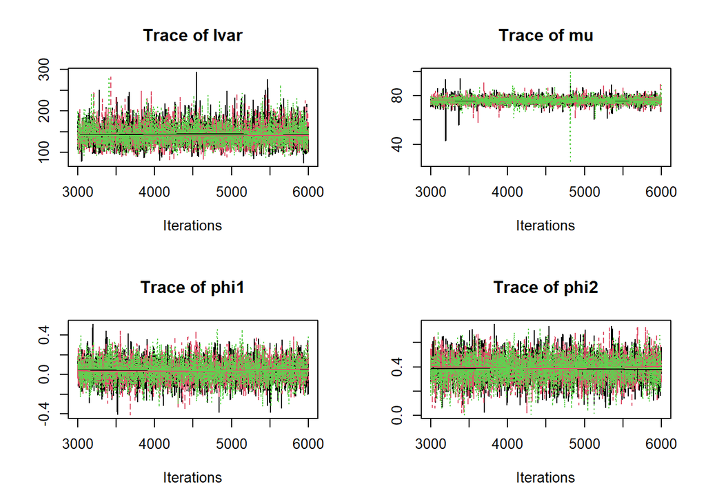

```r
plot(samps_AR2,density=FALSE)
```

```r
gelman.diag(samps_AR2)
```

```
## Potential scale reduction factors:
##
##      Point est. Upper C.I.
## Ivar          1       1.01
## mu            1       1.00
## phi1          1       1.00
## phi2          1       1.00
##
## Multivariate psrf
##
## 1
```

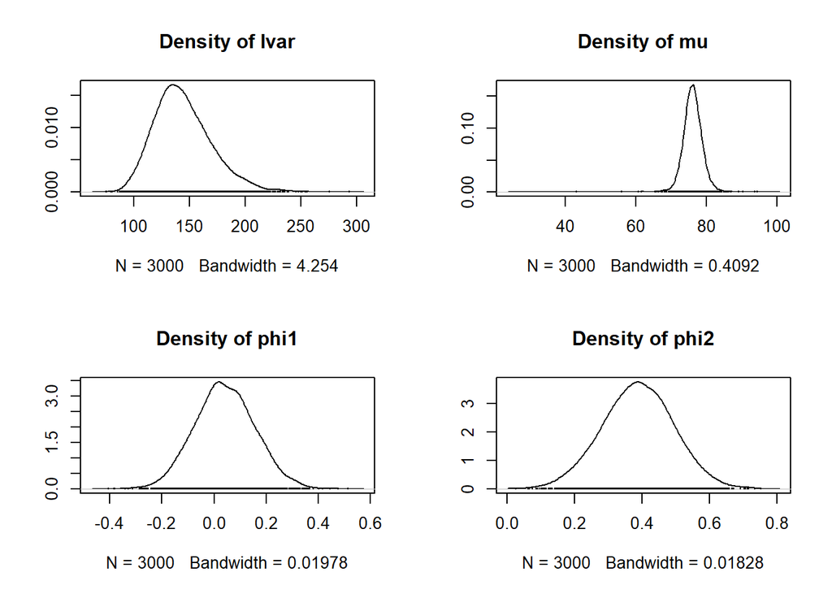

```r
plot(samps_AR2,trace=FALSE)
```

- Do you see evidence of non-convergence? If so, increase iterations.
- If not, interpret the results.

```r
summary(samps_AR2)
```

```
##
## Iterations = 3001:6000
## Thinning interval = 1
## Number of chains = 3
## Sample size per chain = 3000
##
## 1. Empirical mean and standard deviation for each variable,
##    plus standard error of the mean:
##
##           Mean      SD Naive SE Time-series SE
## Ivar 144.30696 25.8770 0.272768       0.445443
## mu    76.07528  2.7789 0.029292       0.031416
## phi1   0.04091  0.1156 0.001218       0.001909
## phi2   0.38704  0.1066 0.001123       0.001746
##
## 2. Quantiles for each variable:
##
##          2.5%       25%      50%      75%    97.5%
## Ivar 101.6251 126.30262 141.2342 159.5286 203.1090
## mu    71.0504  74.46673  76.0532  77.6628  81.4505
## phi1  -0.1797  -0.03663   0.0387   0.1178   0.2698
## phi2   0.1753   0.31589   0.3879   0.4590   0.5937
```

- Based on the parameter estimates, does an AR(1) model seem to suit Jane best, or an AR(2) model?
- What about for Mary?

### 3.3 A Bayesian AR(1) model with a covariate

Next, we add an exogenous covariate (i.e., a variable that is purely a predictor variable) to the AR(1) model. We have information on when each women had her period (score 1) or not (score 0). For this variable, we have filled in scores where there were missing observations, because exogenous variables are not allowed to have missing observations in the analysis. Given the nature of the variable, we could surmise how to complete these observations (if a woman had her period before and after the missing observation, we indicate this missing observation as a period day).

An alternative way to deal with missings in covariates is to specify a likelihood/data model for the covariate as well, next to the dependent variable, or to impute for these observations in another way. This is beyond the scope of this course, however.

#### 3.3a Check out the data.

Load the data for Mary and Jane, and explore their data with (for instance) a time series plot:

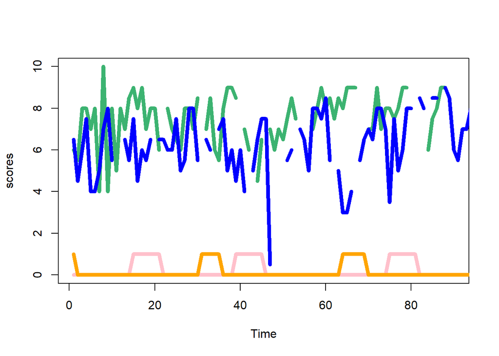

```r
dat_predJane = read.table("Ar1pred_Jane.dat", header=TRUE, na.strings="*")
dat_predMary = read.table("Ar1pred_Mary.dat", header=TRUE, na.strings="*")
mood_J = dat_predJane[,1]
period_J =dat_predJane[,2]
mood_M = dat_predMary[,1]
period_M =dat_predMary[,2]

ts.plot(mood_J/10,col="mediumseagreen",lwd=5, ylab= "scores", ylim=c(0,10))
lines(period_J,col="pink",lwd=5)
lines(period_M,col="orange",lwd=5)
lines(mood_M/10,col="blue",lwd=5)
```

#### 3.3b Fit the model, and interpret the results.

Take a look at the JAGS model code for the AR(1) model with an exogenous predictor (see below, or look in the file `AR1predmodel.txt` - make sure this file is in your working directory). Note that in this model specification, we are estimating an intercept (int) rather than a mean (mu) for mood.

Note that we are estimating a concurrent effect of the variable period on mood.

```r
cat("model{


#####model######
    for (t in 2:nt)
    ###model for timepoint 2 onwards
    {
        y[t] ~ dnorm(muy[t],Ipre)
        ## Ipre is innovation precision
        muy[t] <- int + phi*y[t-1] + b1*x[t]
        ## int is the intercept, phi is autoregressive parameters
    }

    #####priors###########

    Ipre <- inverse(Ivar) ## innovation precision
    Ivar ~ dunif(0,500)   ## innovation variance

    phi~dunif(-1,1) ## autoregression coefficient
      b1~dnorm(0,.001) ## exogenous effect
      b2~dnorm(0,.001) ## exogenous effect (lagged)
    int~dnorm(50,.001) ## intercept



}
")
```

```
## model{
##
##
## #####model######
##  for (t in 2:nt)
##  ###model for timepoint 2 onwards
##  {
##      y[t] ~ dnorm(muy[t],Ipre)
##      ## Ipre is innovation precision
##      muy[t] <- int + phi*y[t-1] + b1*x[t]
##      ## int is the intercept, phi is autoregressive parameters
##  }
##
##  #####priors###########
##
##     Ipre <- inverse(Ivar) ## innovation precision
##     Ivar ~ dunif(0,500)   ## innovation variance
##
##     phi~dunif(-1,1) ## autoregression coefficient
##    b1~dnorm(0,.001) ## exogenous effect
##    b2~dnorm(0,.001) ## exogenous effect (lagged)
##     int~dnorm(50,.001) ## intercept
##
##
##
## }
```

Fit this model to the data for Jane, check the convergence, and interpret the results:

```r
####Jane#####
jags <- jags.model('AR1predmodel.txt',
                   data = list('nt' = length(mood_J),
                               'y' = as.numeric(mood_J),
                               'x' = as.numeric(period_J)

                   ),
                   n.chains = 3) ###compile and initialize jags AR model
```

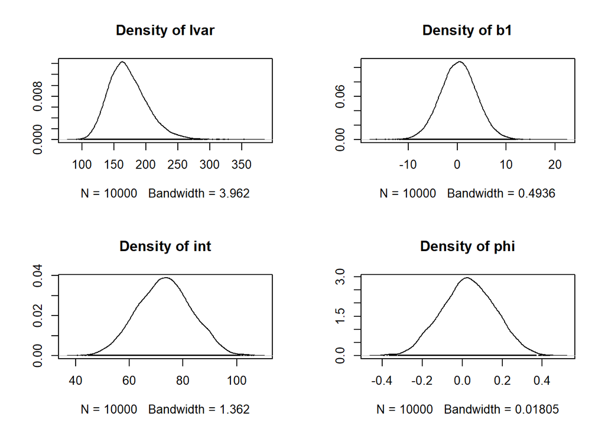

```r
update(jags, 4000) ####burnin

samps=coda.samples(jags,
                   c('phi','b1', 'int', 'Ivar'),
                   10000) ### take samples next to burnin


plot(samps,trace=FALSE) ##plot densities
```

```r
gelman.diag(samps) ###plot gelman rubin stats
```

```
## Potential scale reduction factors:
##
##      Point est. Upper C.I.
## Ivar       1.00       1.00
## b1         1.00       1.00
## int        1.01       1.03
## phi        1.01       1.03
##
## Multivariate psrf
##
## 1.01
```

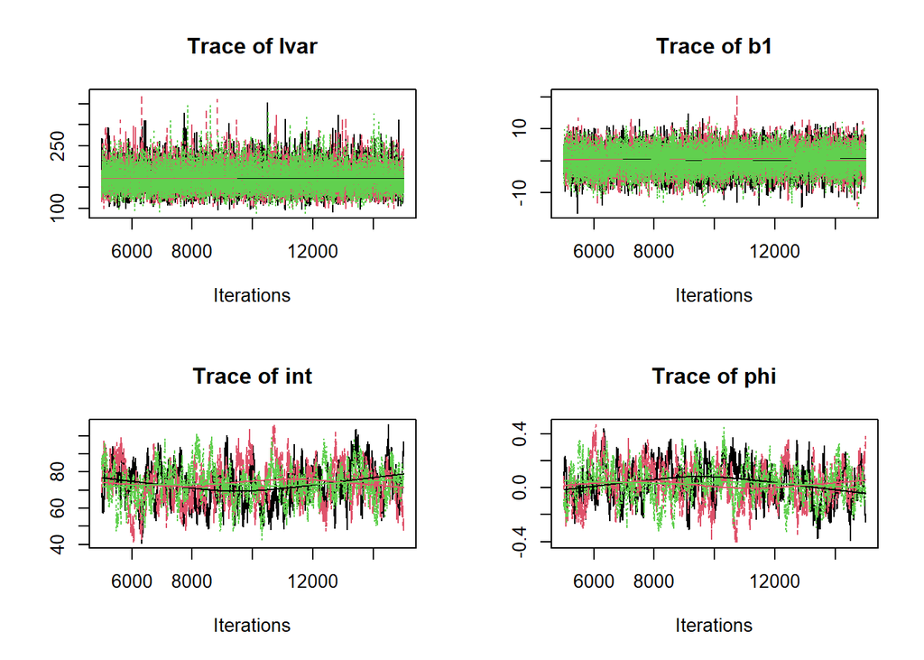

```r
plot(samps,density=FALSE) ##traceplots
```

```r
summary(samps) ##results parameters estimates
```

```
##
## Iterations = 5001:15000
## Thinning interval = 1
## Number of chains = 3
## Sample size per chain = 10000
##
## 1. Empirical mean and standard deviation for each variable,
##    plus standard error of the mean:
##
##           Mean      SD  Naive SE Time-series SE
## Ivar 171.91157 30.3846 0.1754257       0.290195
## b1     0.28723  3.6831 0.0212642       0.037986
## int   73.19092 10.0960 0.0582891       0.691904
## phi    0.03047  0.1338 0.0007728       0.009232
##
## 2. Quantiles for each variable:
##
##         2.5%      25%       50%      75%    97.5%
## Ivar 121.975 150.4527 168.45937 189.8245 240.6798
## b1    -6.958  -2.1657   0.29631   2.7384   7.5810
## int   53.717  66.1600  73.19157  80.0082  92.7093
## phi   -0.228  -0.0611   0.03054   0.1235   0.2879
```

- Do the same for Mary, and compare the results.

## 4 Vector or multivariate autoregressive modeling

In the following, we’ll practice with fitting multivariate autoregressive models: VAR models.

### 4.1 VAR(1) analysis

As a final model we fit a first-order vector autoregressive model for two variables: A bivariate VAR(1) model. The two variables we will model are mood and nervous tension.

- What kind of effects would you expect nervous tension and mood to have on each other over time? What about concurrently?

#### 4.1a Check out the data.

Start by loading the data for both women, and make time series plots:

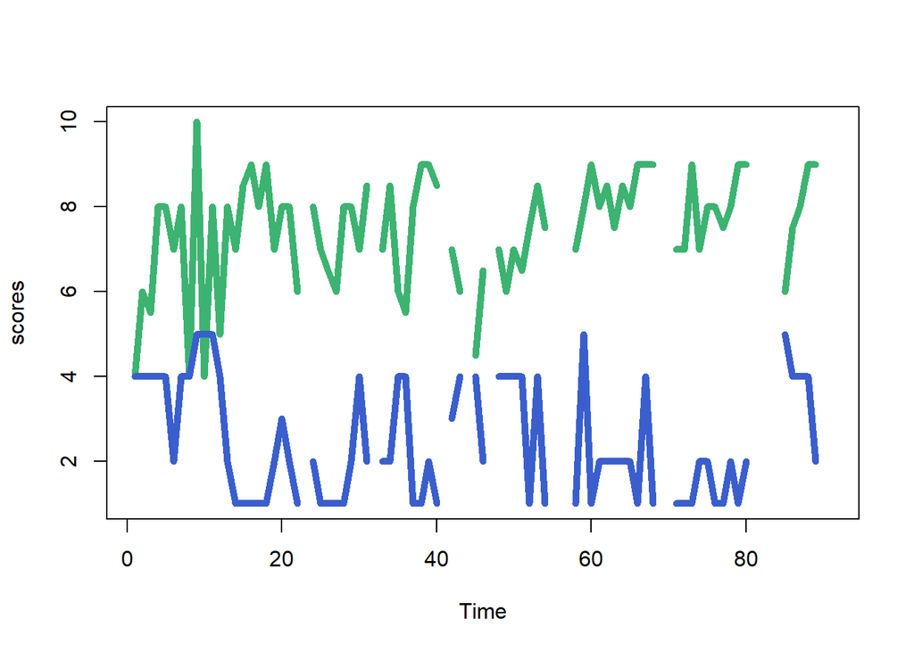

```r
datvar_Jane=data.frame(mydata_Jane$scale,mydata_Jane$nerveuzegespannenheid)
colnames(datvar_Jane) = c("mood", "nervoustension")

datvar_Mary=data.frame(mydata_Mary$scale,mydata_Mary$nerveuzegespannenheid)
colnames(datvar_Mary) = c("mood", "nervoustension")

mood_J = datvar_Jane[,1]
tense_J = datvar_Jane[,2]
ts.plot(mood_J/10,col="mediumseagreen",lwd=5, ylab= "scores", ylim=c(1,10))
lines(tense_J,col="royalblue3",lwd=5)
```

- Judging from looking at the data, do the two variables seem to sync up over time within each woman?

#### Check out the model code.

Now, take a look at the JAGS model code for the bivariate VAR(1) model (also in `VAR1model.txt`, make sure this file is in your working directory.

```r
cat("model{


#####model######
    for (t in 2:nt)

    ###likelihood or data model for timepoint 2 onwards
    {
        y[t,1:2]~dmnorm(muy[t,1:2],Ipre[1:2,1:2])

        #latent centered variables
        z[t,1] <- y[t,1] - mu1
        z[t,2] <- y[t,2] - mu2

        # autoregressive equations
        muy[t,1]<- mu1 + phi11*z[t-1,1] + phi12*z[t-1,2]
        muy[t,2]<- mu2 + phi22*z[t-1,2] + phi21*z[t-1,1]

        #note: mu1 and mu2 are the means for each variable
        # phi11 and phi22 are the autoregressive coefficients for each variable
        # phi 12 and phi21 are the cross-lagged coefficients for each variable
    }

####timepoint 1#######

    z[1,1] <- y[1,1]-mu1 ### centered score for time point 1 for variable 1.
  z[1,2] <- y[1,2]-mu2 ### centered score for time point 1 for variable 2.


####priors###########


###Innovatian variance-covariance matrix, and/or precision matrix

### prior specifications for means and regression coefficients ###

  mu1~dnorm(50,.001) ## mean
  mu2~dnorm(3,.001) ## mean

  phi11~dnorm(0,.001) ## autoregression coefficient
    phi12~dnorm(0,.001) ## cross-lagged coefficient
    phi21~dnorm(0,.001) ## cross-lagged coefficient
    phi22~dnorm(0,.001) ## autoregression coefficient

### prior specifications for the covariance matrix of the innovations ###

  ## priors for the two variances:
  Ivar1 ~ dunif(0,300) ## innovation variance y1
    Ivar2 ~ dunif(0,300) ## innovation variance y2

    ##prior for the correlation among the innovations:
    Icor ~ dunif(-1,1) ## innovation correlation
    ## turning correlation into a covariance:
    Icov <- Icor*sqrt(Ivar1)*sqrt(Ivar2)

    ##Sticking all of the above into one covariance matrix:
    Ivar[1,1] <- Ivar1
  Ivar[2,2] <- Ivar2
  Ivar[2,1] <- Icov
  Ivar[1,2] <- Icov

    ## Turning the covariance matrix into a precision matrix:
  Ipre <- inverse(Ivar)

}
")
```

```
## model{
##
##
## #####model######
##  for (t in 2:nt)
##
##  ###likelihood or data model for timepoint 2 onwards
##  {
##      y[t,1:2]~dmnorm(muy[t,1:2],Ipre[1:2,1:2])
##
##      #latent centered variables
##      z[t,1] <- y[t,1] - mu1
##      z[t,2] <- y[t,2] - mu2
##
##      # autoregressive equations
##      muy[t,1]<- mu1 + phi11*z[t-1,1] + phi12*z[t-1,2]
##      muy[t,2]<- mu2 + phi22*z[t-1,2] + phi21*z[t-1,1]
##
##      #note: mu1 and mu2 are the means for each variable
##      # phi11 and phi22 are the autoregressive coefficients for each variable
##      # phi 12 and phi21 are the cross-lagged coefficients for each variable
##     }
##
## ####timepoint 1#######
##
##  z[1,1] <- y[1,1]-mu1 ### centered score for time point 1 for variable 1.
##   z[1,2] <- y[1,2]-mu2 ### centered score for time point 1 for variable 2.
##
##
## ####priors###########
##
##
## ###Innovatian variance-covariance matrix, and/or precision matrix
##
## ### prior specifications for means and regression coefficients ###
##
##   mu1~dnorm(50,.001) ## mean
##   mu2~dnorm(3,.001) ## mean
##
##   phi11~dnorm(0,.001) ## autoregression coefficient
```

[output cut: 10 more lines]

```
##  ##prior for the correlation among the innovations:
##  Icor ~ dunif(-1,1) ## innovation correlation
##  ## turning correlation into a covariance:
##  Icov <- Icor*sqrt(Ivar1)*sqrt(Ivar2)
##
##  ##Sticking all of the above into one covariance matrix:
##  Ivar[1,1] <- Ivar1
##   Ivar[2,2] <- Ivar2
##   Ivar[2,1] <- Icov
##   Ivar[1,2] <- Icov
##
##  ## Turning the covariance matrix into a precision matrix:
##   Ipre <- inverse(Ivar)
##
## }
```

Fit the model for Jane (note that this time we do not specify initial values; instead, we let JAGS generate them for us):

```r
jags <- jags.model('VAR1model.txt',
                   data = list('nt' = nt,
                               'y' = datvar_Jane
                   ),
                   n.chains = 3)
```

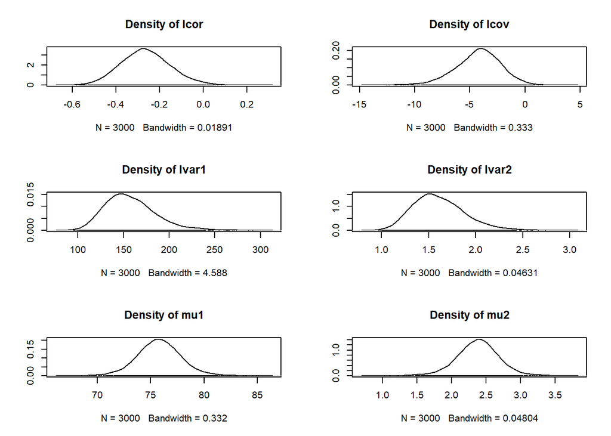

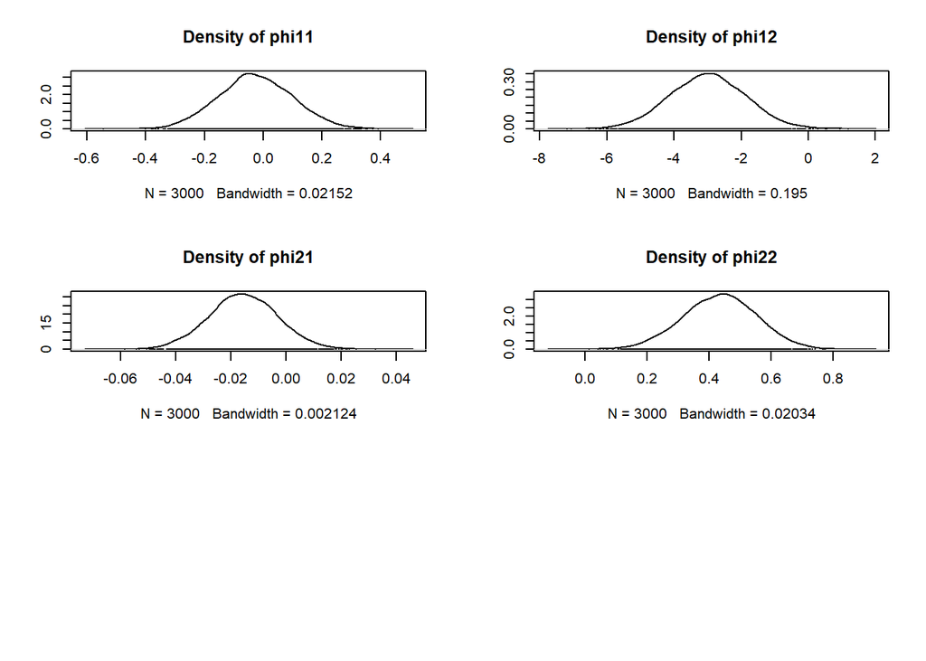

```r
###compile and initialize jags AR model

update(jags, 2000) ####burnin

samps=coda.samples(jags,
                   c('phi11','phi22', 'mu1', 'Ivar1',
                     'phi12','phi21', 'mu2', 'Ivar2',
                     'Icov', 'Icor'),
                   3000) ### take samples next to burnin

plot(samps,trace=FALSE) ## plot densities
```

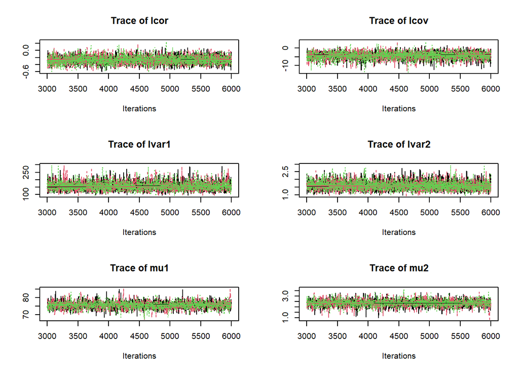

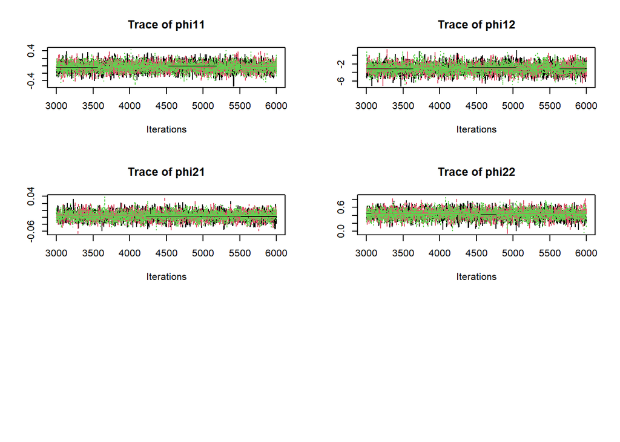

```r
#gelman.diag(samps) ## plot gelman rubin stats

plot(samps,density=FALSE) ## traceplots
```

```r
summary(samps) ##results parameters estimates
```

```
##
## Iterations = 3001:6000
## Thinning interval = 1
## Number of chains = 3
## Sample size per chain = 3000
##
## 1. Empirical mean and standard deviation for each variable,
##    plus standard error of the mean:
##
##            Mean       SD  Naive SE Time-series SE
## Icor   -0.26473  0.11143 0.0011746       0.001937
## Icov   -4.24222  2.03423 0.0214426       0.037326
## Ivar1 157.51520 28.05295 0.2957040       0.501572
## Ivar2   1.60749  0.27346 0.0028825       0.004466
## mu1    75.79613  2.03748 0.0214770       0.048359
## mu2     2.37692  0.30490 0.0032140       0.006993
## phi11  -0.02659  0.12540 0.0013219       0.002130
## phi12  -2.99835  1.13633 0.0119780       0.018648
## phi21  -0.01546  0.01238 0.0001305       0.000209
## phi22   0.43420  0.11853 0.0012494       0.002065
##
## 2. Quantiles for each variable:
##
##            2.5%      25%       50%        75%      97.5%
## Icor   -0.47285  -0.3407  -0.26848  -0.193028  -0.033167
## Icov   -8.54455  -5.4775  -4.12037  -2.876474  -0.490427
## Ivar1 112.48556 137.8536 154.19569 173.685086 223.132437
## Ivar2   1.15747   1.4131   1.57794   1.774784   2.221093
## mu1    71.78124  74.4816  75.77041  77.074136  79.970928
## mu2     1.74859   2.1918   2.38402   2.566965   2.968057
## phi11  -0.26748  -0.1108  -0.02910   0.058440   0.221676
## phi12  -5.21004  -3.7763  -2.99937  -2.232736  -0.767607
## phi21  -0.03983  -0.0237  -0.01557  -0.007109   0.008969
## phi22   0.20030   0.3548   0.43674   0.514410   0.660787
```

- Evaluate the convergence of the model.
- Draw a path model (by hand) based on the results for Jane, leaving out paths for which the sign of the effect is unclear based on the 95% credible intervals (see quantiles).
- Do the same for Mary, and compare the results.

## End of week 1-3 R-lab.

You completed the exercises in R for week 1-3! We hope you have been able to get an impression of the basics of modeling single case time series, and the individual differences in dynamic processes.